# Lending Club Loan Default Rate Prediction Project

#### revol_util

```r
sum(is.na(loan$revol_util))
```

```
## [1] 240
```

```r
#Feature Engineering for revol_util
#impute with median
loan$revol_util[which(is.na(loan$revol_util))] <- median(loan$revol_util, na.rm = T)
```

#### total_rev_hi_lim

```r
sum(is.na(loan$total_rev_hi_lim))/dim(loan)[1]
```

```
## [1] 0.258719
```

```r
summary(loan$total_rev_hi_lim)
```

```
##    Min. 1st Qu.  Median    Mean 3rd Qu.    Max.    NA's
##       0   13300   22300   29695   36800 2013133   66475
```

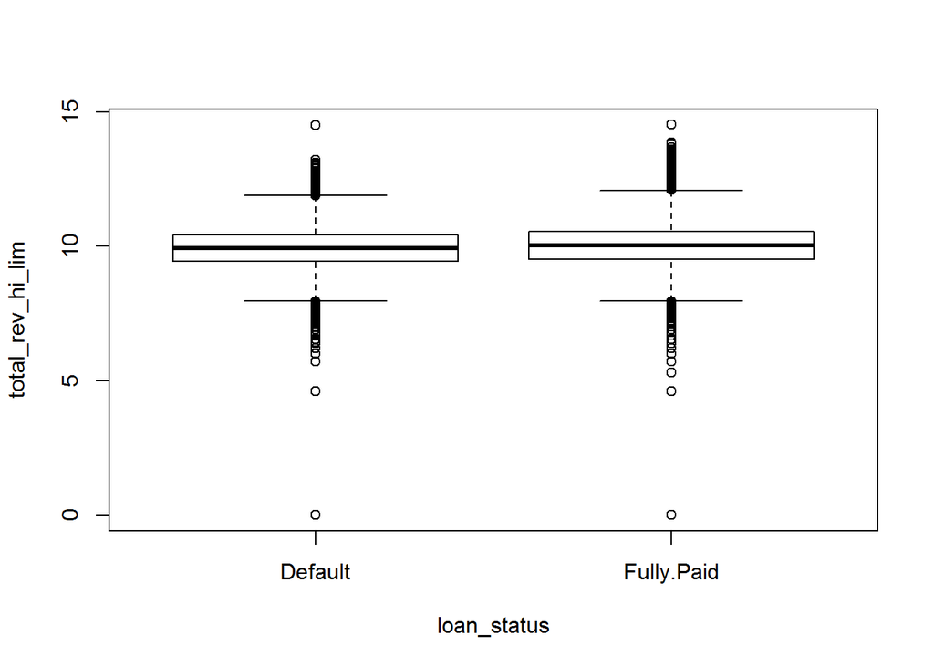

```r
boxplot(log(total_rev_hi_lim + 1) ~ loan_status, data = loan, xlab='loan_status', ylab='total_rev_hi_lim')
```

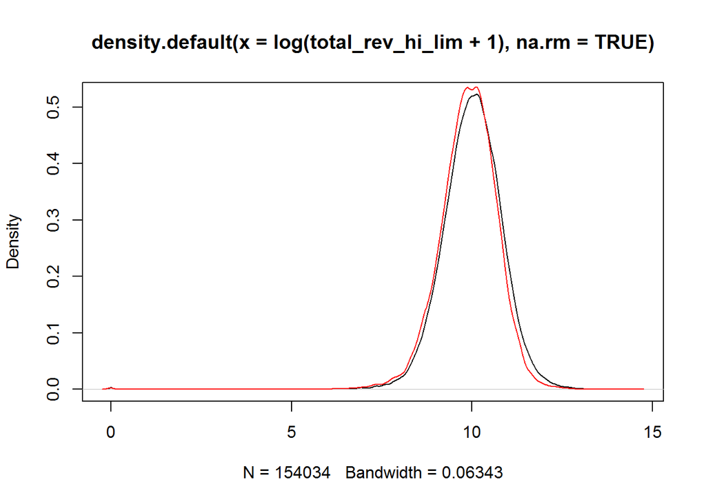

```r
with(subset(loan, loan_status == 'Fully.Paid'), plot(density(log(total_rev_hi_lim + 1), na.rm=TRUE)))
with(subset(loan, loan_status == 'Default'), lines(density(log(total_rev_hi_lim + 1), na.rm=T), col = 'red'))
```

There is no clear difference in the two groups. We just do some feature engineering.

```r
#Feature Engineering for total_rev_hi_lim
#impute with median
loan$total_rev_hi_lim[which(is.na(loan$total_rev_hi_lim))] <- median(loan$total_rev_hi_lim, na.rm = T)

#Take log
loan$log_total_rev_hi_lim <- log(loan$total_rev_hi_lim + 1)
```

### Loan General Features

#### Purpose

```r
unique(loan$purpose)
```

```
##  [1] "credit_card"        "car"                "small_business"
##  [4] "other"              "wedding"            "debt_consolidation"
##  [7] "home_improvement"   "major_purchase"     "medical"
## [10] "moving"             "vacation"           "house"
## [13] "renewable_energy"   "educational"
```

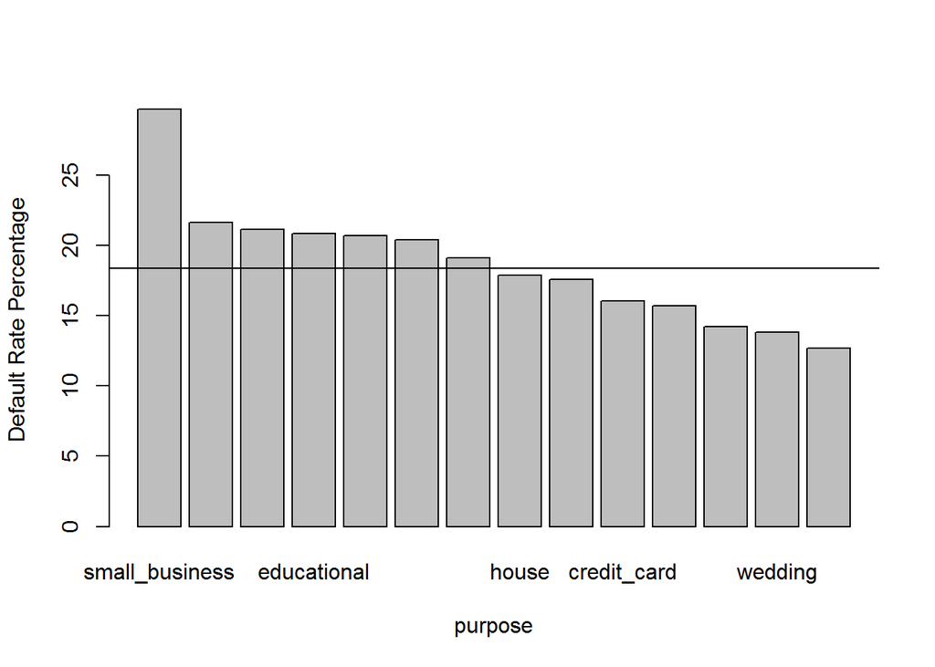

```r
default.rate.by.purpose <- by(loan, loan$purpose, function(x) {return(length(which(x$loan_status == 'Default')) / dim(x)[1] * 100)})
default.rate.by.purpose.sort <-sort(default.rate.by.purpose, decreasing = T)

barplot(default.rate.by.purpose.sort, xlab ="purpose", ylab = "Default Rate Percentage")
abline(h=default_rate)
```

Each group is different, we include this feature as it is.

#### Term

```r
sum(is.na(loan$term))
```

```
## [1] 0
```

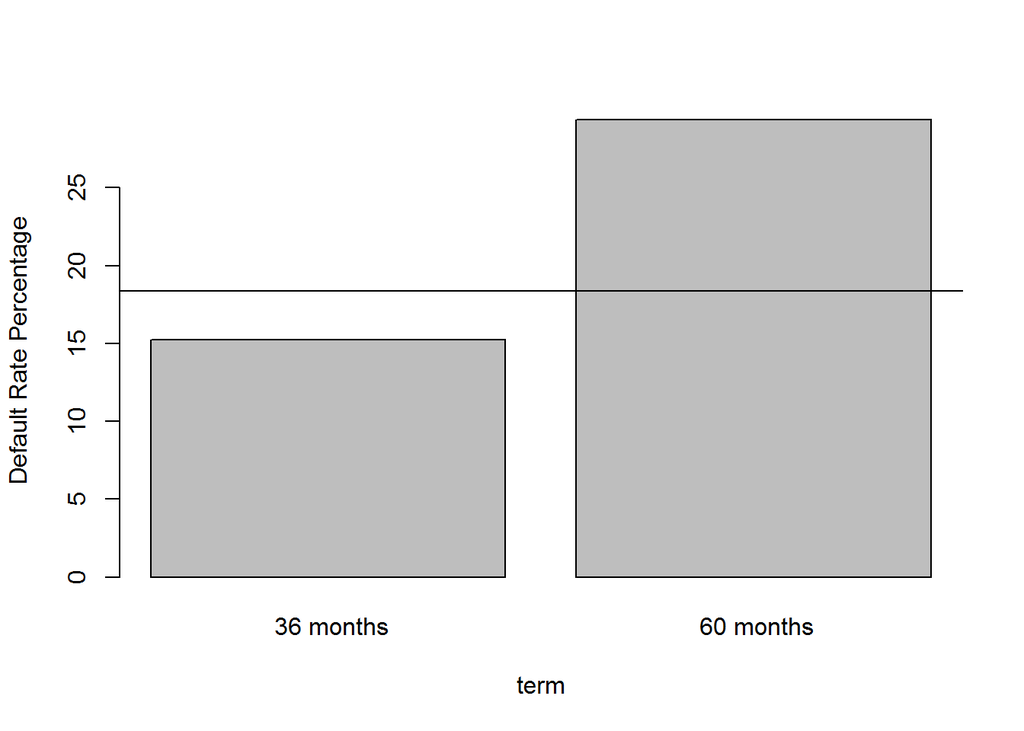

```r
default.rate.by.term <- by(loan, loan$term, function(x) {return(length(which(x$loan_status == 'Default')) / dim(x)[1] * 100)})

barplot(default.rate.by.term, xlab ="term", ylab = "Default Rate Percentage")
abline(h=default_rate)
```

Clearly, the default rate is higher in 60 months group.

#### initial_list_status

```r
sum(is.na(loan$initial_list_status))
```

```
## [1] 0
```

Plot

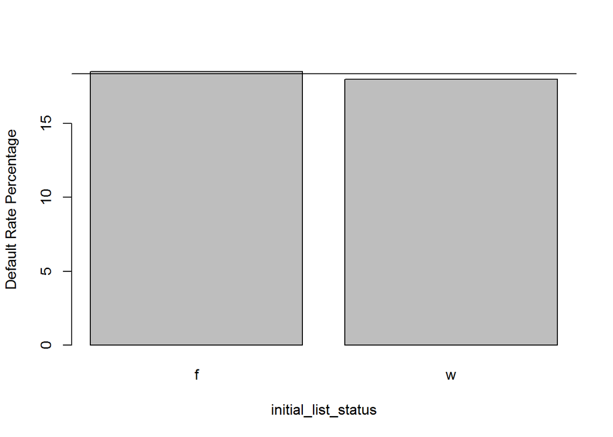

```r
default.rate.by.initial_list_status <- by(loan, loan$initial_list_status, function(x) {return(length(which(x$loan_status == 'Default')) / dim(x)[1] * 100)})

barplot(default.rate.by.initial_list_status, xlab ="initial_list_status", ylab = "Default Rate Percentage")
abline(h=default_rate)
```

There is some slightly difference between the two groups, we keep it.

### Loan payment feature

#### loan_amnt

```r
sum(is.na(loan$loan_amnt))
```

```
## [1] 0
```

Plot

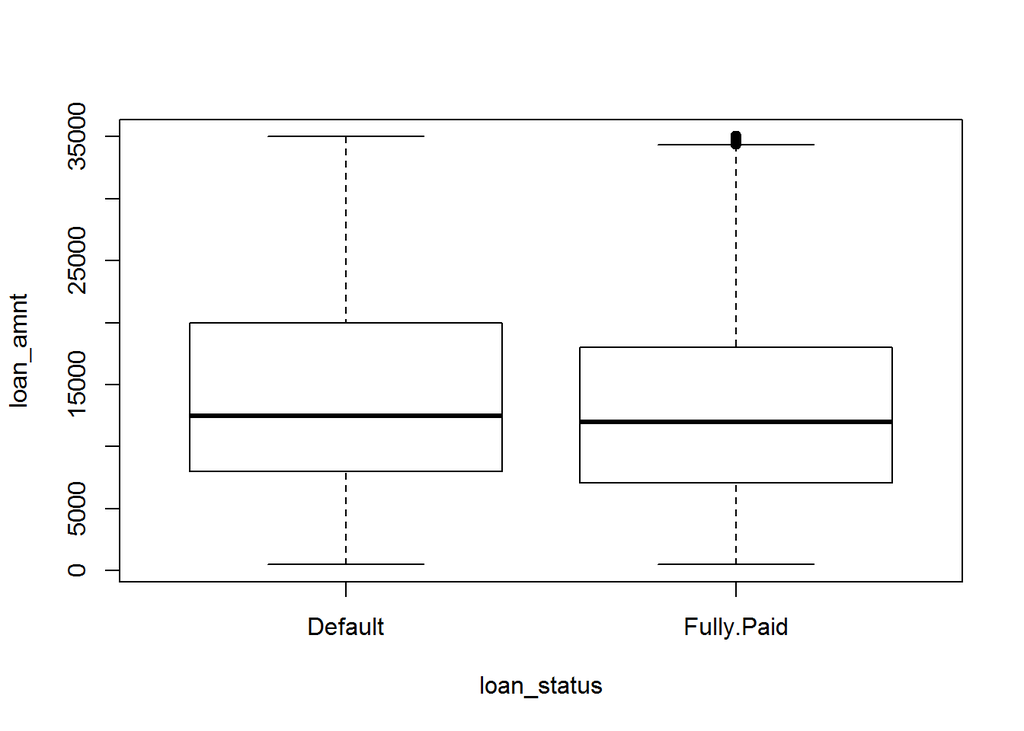

```r
boxplot(loan_amnt ~ loan_status, data = loan, xlab='loan_status', ylab='loan_amnt')
```

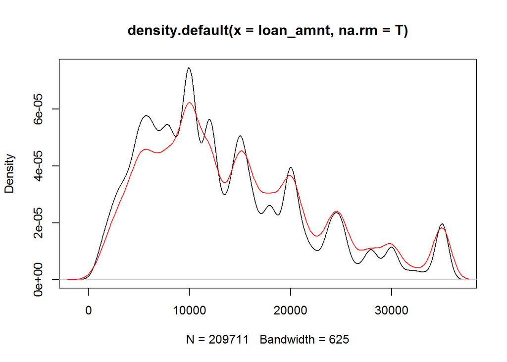

```r
with(subset(loan, loan_status == 'Fully.Paid'), plot(density(loan_amnt, na.rm = T)))
with(subset(loan, loan_status == 'Default'), lines(density(loan_amnt, na.rm = T), col = 'red'))
```

There is some weak pattern that the default group have larger loan amount.

```r
#feature engineering for loan_amnt
loan$log_loan_amnt <- log(loan$loan_amnt + 1)
```

#### installment

```r
sum(is.na(loan$installment))/dim(loan)[1]
```

```
## [1] 0
```

```r
cor(loan$installment, loan$loan_amnt)
```

```
## [1] 0.9552434
```

Because this feature is highly correlated with loan_amnt, we drop it.

#### funded_amnt

```r
sum(is.na(loan$funded_amnt))
```

```
## [1] 0
```

```r
cor(loan$funded_amnt, loan$loan_amnt)
```

```
## [1] 0.9975372
```

Because this feature is highly correlated with loan_amnt, we drop it.

#### funded_amnt_inv

```r
cor(loan$funded_amnt_inv, loan$loan_amnt)
```

```
## [1] 0.9897869
```

Because this feature is highly correlated with loan_amnt, we drop it.

#### last_pymnt_amnt

```r
sum(is.na(loan$last_pymnt_amnt))/dim(loan)[1]
```

```
## [1] 0
```

Plot

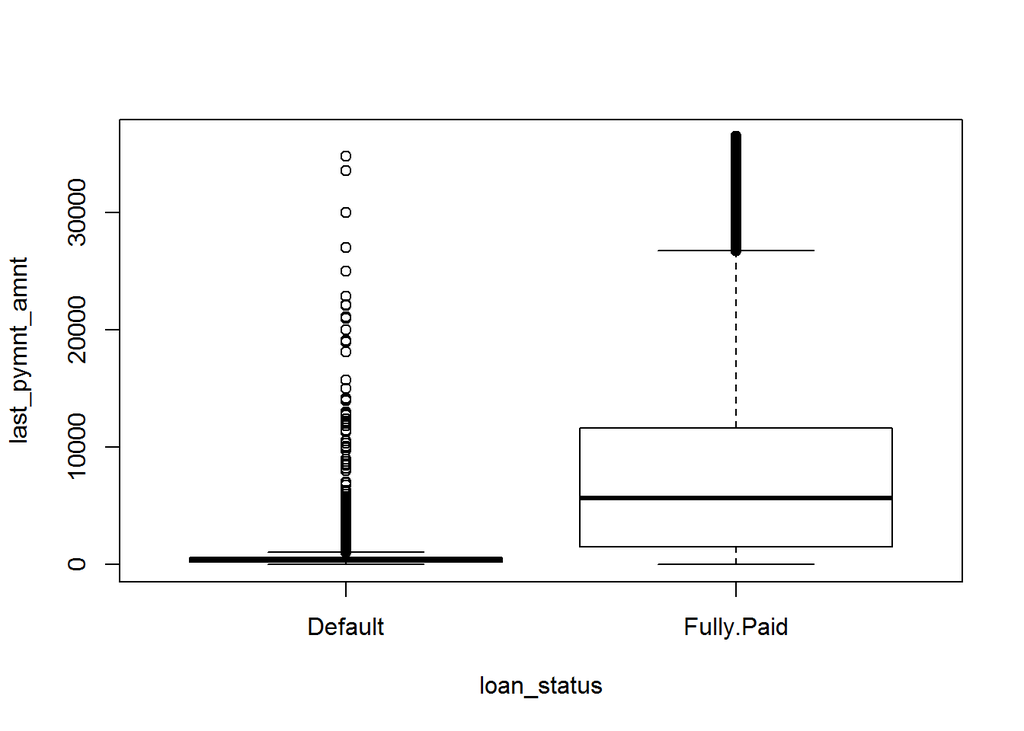

```r
boxplot(last_pymnt_amnt ~ loan_status, data = loan, xlab='loan_status', ylab='last_pymnt_amnt')
```

The two groups show significant difference on this feature. This is a very strong predictor.

```r
#feature engineering for last_pymnt_amnt
#divide by loan_amount
loan$last_pymnt_amnt_to_loan_amnt_percent <- loan$last_pymnt_amnt / loan$loan_amnt * 100
```

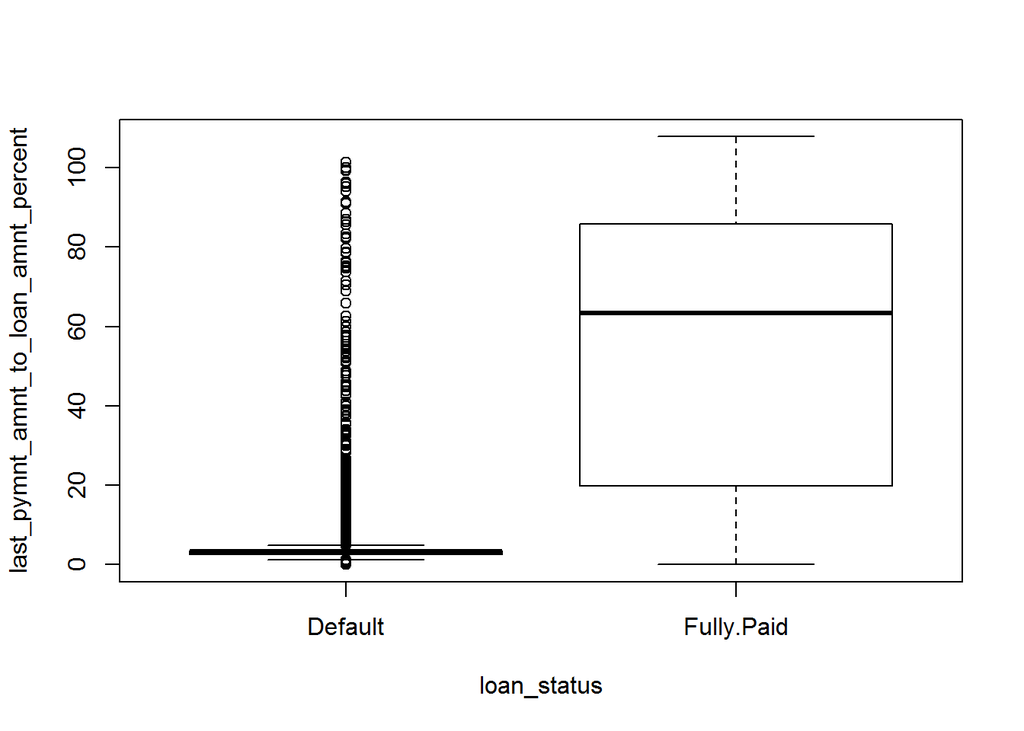

```r
boxplot(last_pymnt_amnt_to_loan_amnt_percent ~ loan_status, data = loan, xlab='loan_status', ylab='last_pymnt_amnt_to_loan_amnt_percent')
```

It seems this feature will be a too strong predictor.

#### pymnt_plan

```r
table(loan$pymnt_plan)
```

```
##
##      n      y
## 256937      2
```

Drop this feature.

#### recoveries

```r
sum(is.na(loan$recoveries))
```

```
## [1] 0
```

Plot

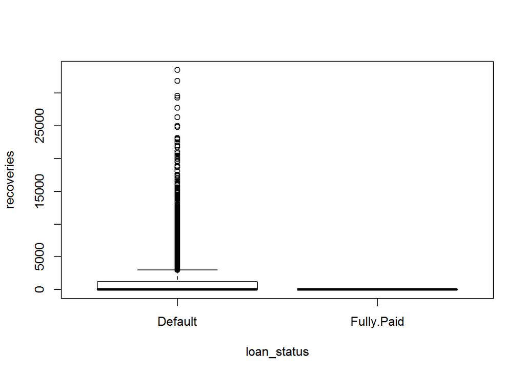

```r
boxplot(recoveries ~ loan_status, data = loan, xlab='loan_status', ylab='recoveries')
```

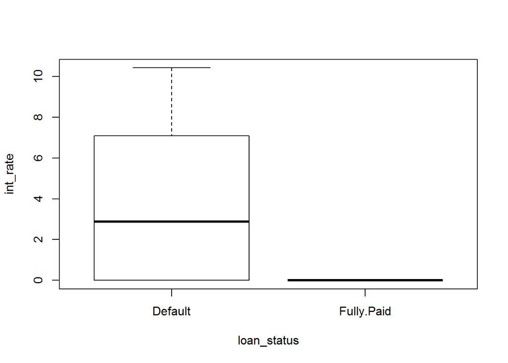

```r
boxplot(log(recoveries + 1) ~ loan_status, data = loan, xlab='loan_status', ylab='int_rate')
```

Do not use this feature because this happens only after charged off.

#### total_rec_late_fee

```r
sum(is.na(loan$total_rec_late_fee))
```

```
## [1] 0
```

Plot

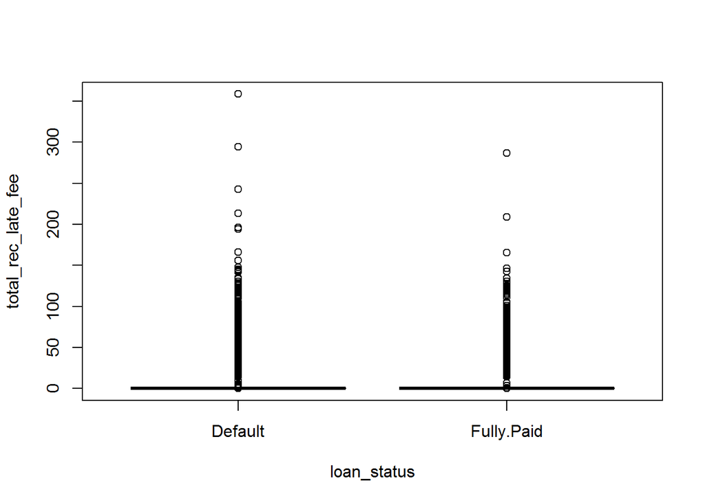

```r
boxplot(total_rec_late_fee ~ loan_status, data = loan, xlab='loan_status', ylab='total_rec_late_fee')
```

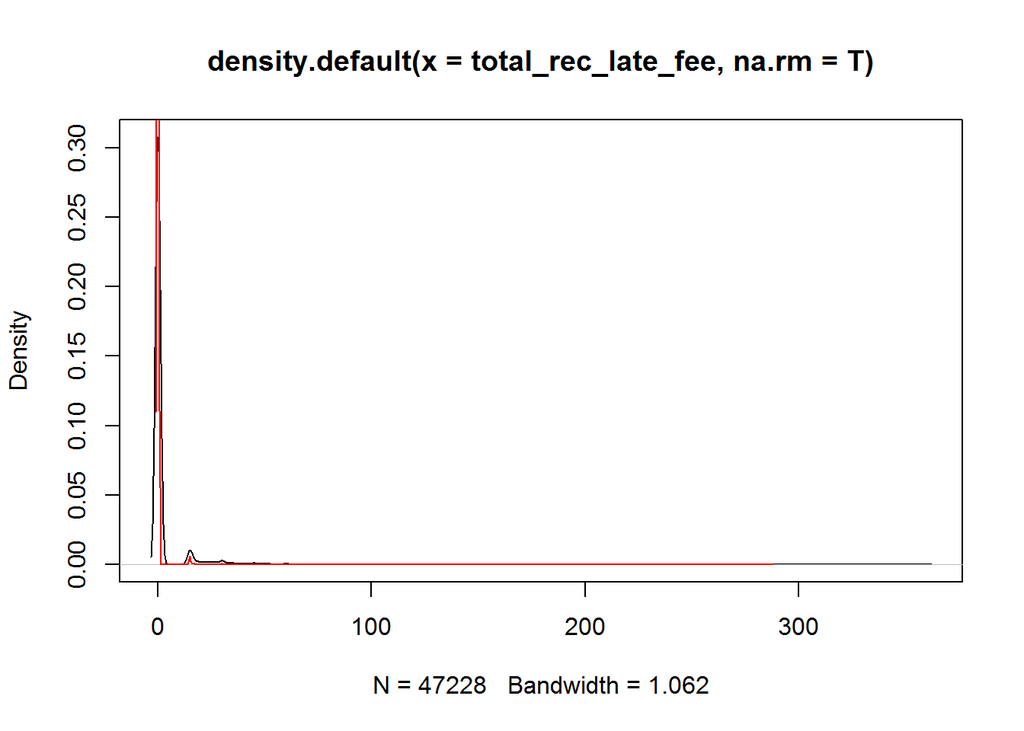

```r
with(subset(loan, loan_status == 'Default'), plot(density(total_rec_late_fee, na.rm = T)))
with(subset(loan, loan_status == 'Fully.Paid'), lines(density(total_rec_late_fee, na.rm = T), col = 'red'))
```

Most values for this feature are 0, drop it.

### Feature Selection

Based on the above analysis, the features selected are: ‘addr_state’, ‘emp_length’, ‘home_ownership’, ‘annual_inc’, ‘verification_status’, ‘dti’, ‘inq_last_6mths’, ‘total_acc’, ‘tot_cur_bal’, ‘open_acc’, ‘acc_now_delinq’, ‘delinq_2yrs’, ‘collections_12_mths_ex_med’, ‘pub_rec’, ‘revol_bal’, ‘revol_util’,‘total_rev_hi_lim’, ‘purpose’, ‘term’, ‘initial_list_status’, ‘loan_amnt’, ‘last_pymnt_amnt’

### Missing value treatment

In our first home work assignment, we just delete those features that have more than 80 percent missing values. But this time, we do some analysis for them to see if the missing rate for a certain feature is different in the two groups.

```r
# to get the column names of those with more than 80% percent mising values
num.NA <- sort(sapply(loan, function(x) { sum(is.na(x))} ), decreasing = TRUE)
missing.col <- names(num.NA)[which(num.NA > 0.8 * dim(loan)[1])]

default.group <- subset(loan, loan_status == 'Default')[, missing.col]
paid.group <- subset(loan, loan_status == 'Fully.Paid')[, missing.col]

# Calculate the missing rate
default.group.na.rate <- sapply(default.group , function(x) { sum(is.na(x)) / dim(default.group)[1] * 100})

paid.group.na.rate <- sapply(paid.group, function(x) { sum(is.na(x)) / dim(paid.group)[1] * 100})

missing.rate <-rbind(default.group.na.rate, paid.group.na.rate)
```

```r
missing.rate.df <- as.data.frame(missing.rate)
missing.rate.df[, 1:6]
```

```
##                       annual_inc_joint dti_joint   il_util
## default.group.na.rate        100.00000 100.00000 100.00000
## paid.group.na.rate            99.99952  99.99952  99.93992
##                       mths_since_rcnt_il open_acc_6m open_il_6m
## default.group.na.rate          100.00000   100.00000  100.00000
## paid.group.na.rate              99.93324    99.93133   99.93133
```

```r
missing.rate.df[, 7:12]
```

```
##                       open_il_12m open_il_24m total_bal_il open_rv_12m
## default.group.na.rate   100.00000   100.00000    100.00000   100.00000
## paid.group.na.rate       99.93133    99.93133     99.93133    99.93133
##                       open_rv_24m max_bal_bc
## default.group.na.rate   100.00000  100.00000
## paid.group.na.rate       99.93133   99.93133
```

```r
missing.rate.df[, 13:18]
```

```
##                        all_util    inq_fi total_cu_tl inq_last_12m
## default.group.na.rate 100.00000 100.00000   100.00000    100.00000
## paid.group.na.rate     99.93133  99.93133    99.93133     99.93133
##                       mths_since_last_record mths_since_last_major_derog
## default.group.na.rate               86.99712                    80.76353
## paid.group.na.rate                  87.34783                    81.50264
```

Based on the above analysis, there is no difference in terms of missing value rate in the two groups. Our missing value treatment is fine.

### Feature Engineering

We combine all the feature engineering we do in the above and put it one function

```r
applyFeatureEngineering <- function(data)
{
    # Feature engineering for addr_state > state_default_level
    default_state <- by(data, data$addr_state, function(x){return(length(which(x$loan_status == 'Default')) / dim(x)[1] * 100)})
    data$state_default_level <- ifelse(data$addr_state %in% names(default_state)[which(default_state <= quantile(default_state, 0.25))], 'low', ifelse(data$addr_state %in% names(default_state)[which(default_state <= quantile(default_state, 0.5))], 'lowmedium', ifelse(data$addr_state %in% names(default_state)[which(default_state <= quantile(default_state, 0.75))], 'mediumhigh', 'high')))

    #featue engineering for emp_length
    #divide into three groups based years '>5' '<=5', 'Missing'
    data$emp_length_sim <- ifelse(data$emp_length %in% c('10+ years', '8 years','9 years','5 years','6 years','7 years'), '>= 5', ifelse(data$emp_length %in% c('< 1 year', '1 year','2 years','3 years','4 years'), '< 5', 'Missing'))

    #feature engineering for home_ownership
    data$home_ownership1 <- ifelse(data$home_ownership %in% c('ANY', 'NONE', 'OTHER'), 'OTHER', data$home_ownership)

    #feature engineering for annual_inc
    data$annual_inc <- ifelse(!is.na(data$annual_inc_joint), data$annual_inc_joint, data$annual_inc)
    # missing value, impute with median
    data$annual_inc[which(is.na(data$annual_inc))] <- median(data$annual_inc, na.rm = T)
    #option 1. take log
    data$log_annual_inc <- log(data$annual_inc + 1)
    #option 2. Divide by loan_amnt
    data$annual_inc_to_loan_amnt_percent <- data$annual_inc / data$loan_amnt * 100

    #feature engineering for dti
    data$dti <- ifelse(!is.na(data$dti_joint), data$dti_joint, data$dti)

    #feature engineering for inq_last_6mths
    data$inq_last_6mths[which(is.na(data$inq_last_6mths))] <- median(data$inq_last_6mths, na.rm = TRUE)
    data$inq_last_6mths_level <- ifelse(data$inq_last_6mths == 0, 'low', ifelse(data$inq_last_6mths <= 5, 'medium', 'high'))

    #Feature engineering for total_acc
    data$total_acc[which(is.na(data$total_acc))] <- median(data$total_acc, na.rm = T)

    #Feature engineering for tot_cur_bal
    # missing value, impute with median
    data$tot_cur_bal[which(is.na(data$tot_cur_bal))] <- median(data$tot_cur_bal, na.rm = T)
    #option 1. take log
    data$log_tot_cur_bal <- log(data$tot_cur_bal + 1)
    #option 2. Divide by loan_amnt
    data$tot_cur_bal_to_loan_amnt_percent <- data$tot_cur_bal / data$loan_amnt * 100

    #Feature Engineering for open_acc
    data$open_acc[which(is.na(data$open_acc))] <- median(data$open_acc, na.rm = T)

    #Feature engineering for acc_now_delinq
    data$acc_now_delinq[which(is.na(data$acc_now_delinq))] <- 0
    data$acc_now_delinq <- ifelse(data$acc_now_delinq == 0, 0, 1)

    #Feature engineering for delinq_2yrs
    #impute missing value with median
    data$delinq_2yrs[which(is.na(data$delinq_2yrs))] <- median(data$delinq_2yrs, na.rm = T)
    data$delinq_2yrs_level <- ifelse(data$delinq_2yrs == 0, 'low', ifelse(data$delinq_2yrs <= 5, 'medium', 'high'))

    #feature engineering for collections_12_mths_ex_med
    #impute with zero for NA, which is more reasonable
    data$collections_12_mths_ex_med[which(is.na(data$collections_12_mths_ex_med))] <- 0
    data$collections_12_mths_ex_med_level <- ifelse(data$collections_12_mths_ex_med == 0, 'low', ifelse(data$collections_12_mths_ex_med ==  1, 'medium', 'high'))

    #feature engineering for pub_rec

    #impute missing value with median
    data$pub_rec[which(is.na(data$pub_rec))] <- median(data$pub_rec, na.rm = T)
    data$pub_rec <- ifelse(data$pub_rec == 0, 'low', ifelse(data$pub_rec < 3, 'medium', 'high'))

    #Feature Engineering for revol_bal
    #option 1. take log
    data$log_revol_bal <- log(data$revol_bal + 1)
    #option 2. Divide by loan_amnt
    data$revol_bal_to_loan_amnt_percent <- data$revol_bal / data$loan_amnt * 100

    #Feature Engineering for revol_util
    #impute with median
    data$revol_util[which(is.na(data$revol_util))] <- median(data$revol_util, na.rm = T)

    #Feature Engineering for total_rev_hi_lim
    #impute with median
    data$total_rev_hi_lim[which(is.na(data$total_rev_hi_lim))] <- median(data$total_rev_hi_lim, na.rm = T)
    #Take log
    data$log_total_rev_hi_lim <- log(data$total_rev_hi_lim + 1)

    #feature engineering for loan_amnt
    data$log_loan_amnt <- log(data$loan_amnt + 1)

    #feature engineering for last_pymnt_amnt
    #divide by loan_amount
    data$last_pymnt_amnt_to_loan_amnt_percent <- data$last_pymnt_amnt / data$loan_amnt * 100

    return (data)
}
```

## Build Model

### Data split

```r
set.seed(1)
train.ind <- sample(1:dim(loan)[1], 0.7 * dim(loan)[1])

#selected.features <- c('loan_status','addr_state', 'state_default_level', 'emp_length', 'emp_length_sim', 'home_ownership','home_ownership1', 'annual_inc', 'log_annual_inc', 'annual_inc_to_loan_amnt_percent', 'verification_status', 'dti', 'inq_last_6mths', 'inq_last_6mths_level', 'total_acc', 'tot_cur_bal', 'log_tot_cur_bal', 'tot_cur_bal_to_loan_amnt_percent', 'open_acc', 'acc_now_delinq', 'delinq_2yrs', 'delinq_2yrs_level', 'collections_12_mths_ex_med','pub_rec', 'revol_bal', 'log_revol_bal', 'revol_bal_to_loan_amnt_percent', 'revol_util', 'total_rev_hi_lim', 'log_total_rev_hi_lim', 'purpose', 'term', 'initial_list_status', 'loan_amnt', 'log_loan_amnt', 'last_pymnt_amnt', 'last_pymnt_amnt_to_loan_amnt_percent')

#Simpler vectors - log form
#selected.features <- c('loan_status', 'state_default_level', 'emp_length_sim', 'home_ownership1', 'log_annual_inc', 'verification_status', 'dti', 'inq_last_6mths_level', 'total_acc', 'log_tot_cur_bal', 'open_acc', 'acc_now_delinq', 'delinq_2yrs_level', 'collections_12_mths_ex_med', 'pub_rec', 'log_revol_bal', 'revol_util', 'log_total_rev_hi_lim', 'purpose', 'term',  'initial_list_status', 'log_loan_amnt')

#Add payment feature 'last_pymnt_amnt_to_loan_amnt_percent'
selected.features <- c('loan_status', 'state_default_level', 'emp_length_sim', 'home_ownership1', 'log_annual_inc', 'verification_status', 'dti', 'inq_last_6mths_level', 'total_acc', 'log_tot_cur_bal', 'open_acc', 'acc_now_delinq', 'delinq_2yrs_level', 'collections_12_mths_ex_med', 'pub_rec', 'log_revol_bal', 'revol_util', 'log_total_rev_hi_lim', 'purpose', 'term',  'initial_list_status', 'log_loan_amnt', 'last_pymnt_amnt_to_loan_amnt_percent')


train <- loan[train.ind, selected.features]
test <- loan[-train.ind, selected.features]
```

### Logistic Model

First we try logistic model.

```r
#Log Form
#formula <- 'loan_status' ~ 'state_default_level' + 'emp_length_sim' + 'home_ownership1' + 'log_annual_inc' + 'verification_status' + 'dti' + 'inq_last_6mths_level' + 'total_acc' + 'log_tot_cur_bal' + 'open_acc' + 'acc_now_delinq' + 'delinq_2yrs_level' + 'collections_12_mths_ex_med' + 'pub_rec' + 'log_revol_bal' + 'revol_util' + 'log_total_rev_hi_lim' + 'purpose' + 'term' +  'initial_list_status' + 'log_loan_amnt' + 'last_pymnt_amnt_to_loan_amnt_percent'


#Divide By Loan Amount
#formula2 <- 'loan_status' ~ 'addr_state' + 'emp_length' + 'home_ownership' + 'annual_inc_to_loan_amnt_percent' + 'verification_status' + 'dti' + 'inq_last_6mths' + 'total_acc' + 'tot_cur_bal_to_loan_amnt_percent' + 'open_acc' + 'acc_now_delinq' + 'delinq_2yrs_level' + 'collections_12_mths_ex_med' + 'pub_rec' + 'revol_bal_to_loan_amnt_percent' + 'revol_util' + 'log_total_rev_hi_lim' + 'purpose' + 'term' +  'initial_list_status' + 'log_loan_amnt' + 'last_pymnt_amnt_to_loan_amnt_percent'

#All Original Features
#formula3 <- 'loan_status' ~ 'addr_state' + 'emp_length' + 'home_ownership' + 'annual_inc' + 'verification_status' + 'dti' + 'inq_last_6mths' + 'total_acc' + 'tot_cur_bal' + 'open_acc' + 'acc_now_delinq' + 'delinq_2yrs' + 'collections_12_mths_ex_med' + 'pub_rec' + 'revol_bal' + 'revol_util' +'total_rev_hi_lim' + 'purpose' + 'term' +  'initial_list_status' + 'loan_amnt' + 'last_pymnt_amnt'

formula <- loan_status ~.

lr.model <- glm(formula, data=train, family =binomial)
```

#### Predict and plot

We evaluate our model for test dataset

```r
library(pROC)
```

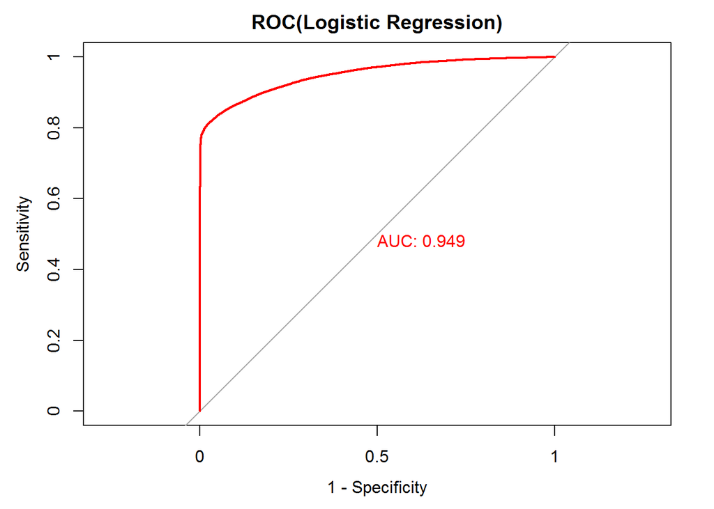

```r
predict_loan_status_lr = predict(lr.model, test, type="response")

rocCurve_lr = roc(response = test$loan_status, predictor = predict_loan_status_lr)
auc_curve = auc(rocCurve_lr)

plot(rocCurve_lr,legacy.axes = TRUE,print.auc = TRUE,col="red",main="ROC(Logistic Regression)")
```

We combine the metrics into a table

```r
library(caret)
```

```r
table_perf = data.frame(model=character(0),
                        auc=numeric(0),
                        accuracy=numeric(0),
                        sensitivity=numeric(0),
                        specificity=numeric(0),
                        kappa=numeric(0),
                        stringsAsFactors = FALSE
                        )

predict_loan_status_label = ifelse(predict_loan_status_lr<0.3,"Default","Fully.Paid")
c = confusionMatrix(predict_loan_status_label,test$loan_status, positive="Fully.Paid")

table_perf[1,] = c("logistic regression",
  round(auc_curve,3),
  as.numeric(round(c$overall["Accuracy"],3)),
  as.numeric(round(c$byClass["Sensitivity"],3)),
  as.numeric(round(c$byClass["Specificity"],3)),
  as.numeric(round(c$overall["Kappa"],3))
  )

tail(table_perf,1)
```

```
##                 model   auc accuracy sensitivity specificity kappa
## 1 logistic regression 0.949    0.876       0.981       0.409 0.485
```

### Logistic Regression for last_pymnt_amnt only

```r
formula.one <- loan_status ~ last_pymnt_amnt_to_loan_amnt_percent

lr.model.one <- glm(formula.one, data=train, family =binomial)
```

#### Predict and plot

We evaluate our model for test dataset

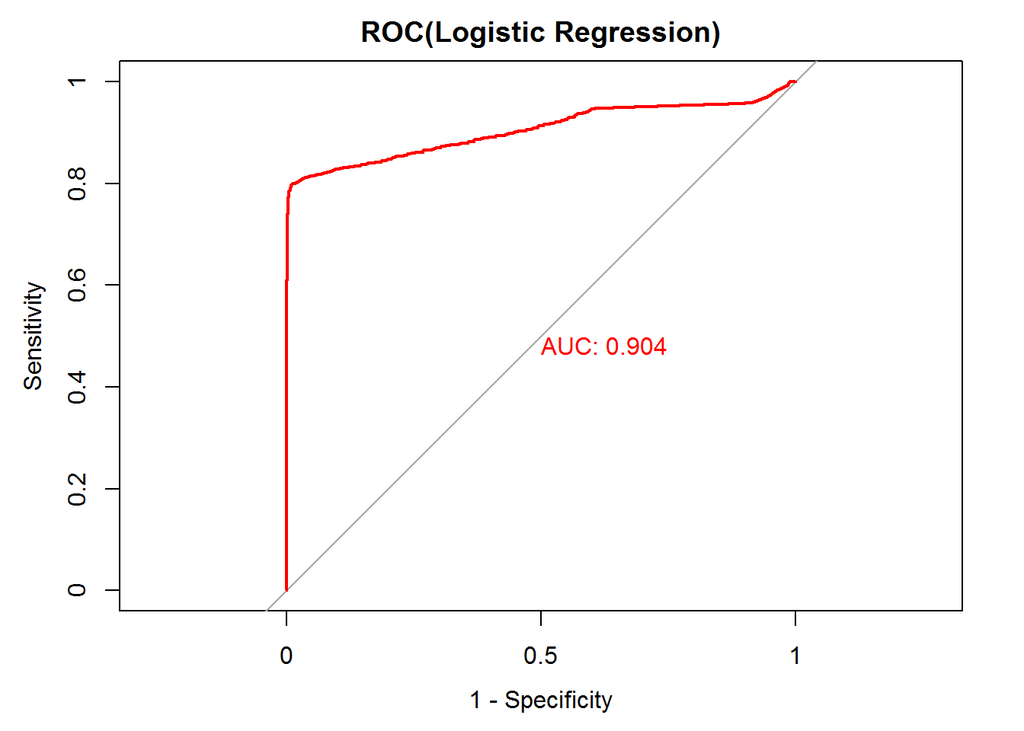

```r
predict_loan_status_lr_one = predict(lr.model.one, test, type="response")

rocCurve_lr_one = roc(response = test$loan_status, predictor = predict_loan_status_lr_one)
auc_curve = auc(rocCurve_lr_one)

plot(rocCurve_lr_one,legacy.axes = TRUE,print.auc = TRUE,col="red",main="ROC(Logistic Regression)")
```

### Decision Tree

```r
library(rpart)
formula <- loan_status ~ .
tree <- rpart(formula, method = 'class', data = train, control=rpart.control(cp = 0.0001))
```

#### Predict and Plot

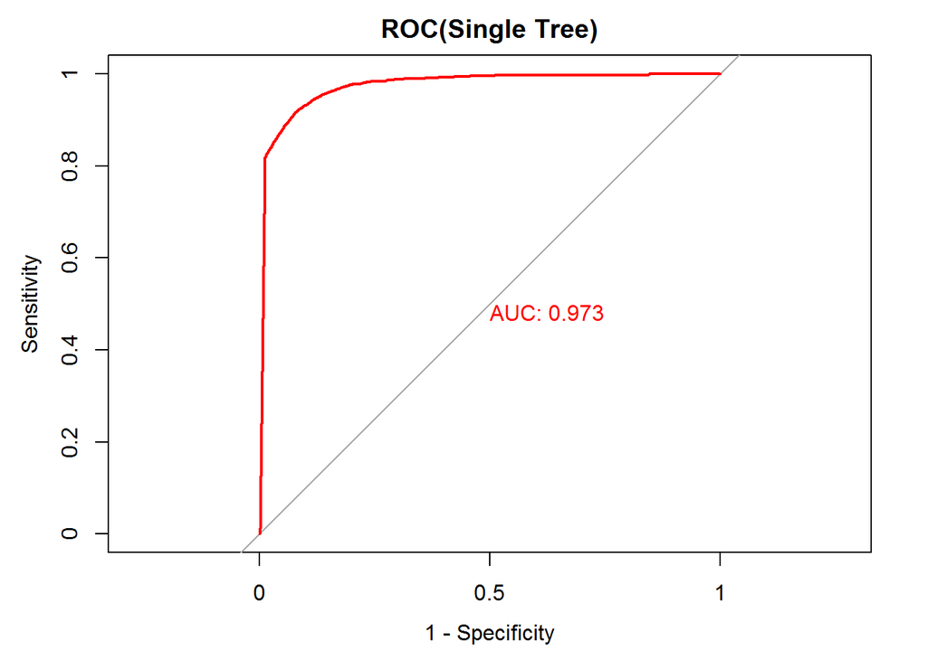

```r
predict_loan_status_tree = predict(tree, test, 'prob')

predict_loan_status_tree = as.data.frame(predict_loan_status_tree)$Fully.Paid

rocCurve_tree = roc(response = test$loan_status, predictor = predict_loan_status_tree)
auc_curve = auc(rocCurve_tree)

plot(rocCurve_tree,legacy.axes = TRUE,print.auc = TRUE,col="red",main="ROC(Single Tree)")
```

Combine Metrics

```r
predict_loan_status_label = ifelse(predict_loan_status_tree<0.3,"Default","Fully.Paid")
c = confusionMatrix(predict_loan_status_label,test$loan_status, positive="Fully.Paid")

table_perf[2,] = c("Single Tree",
  round(auc_curve,3),
  as.numeric(round(c$overall["Accuracy"],3)),
  as.numeric(round(c$byClass["Sensitivity"],3)),
  as.numeric(round(c$byClass["Specificity"],3)),
  as.numeric(round(c$overall["Kappa"],3))
  )

tail(table_perf,1)
```

```
##         model   auc accuracy sensitivity specificity kappa
## 2 Single Tree 0.973    0.942        0.98       0.773 0.796
```

### Bagging

```r
library(ipred)
formula <- loan_status ~.
bag.model <- bagging(formula, data = train, coob = T)
```

#### Predict and Plot

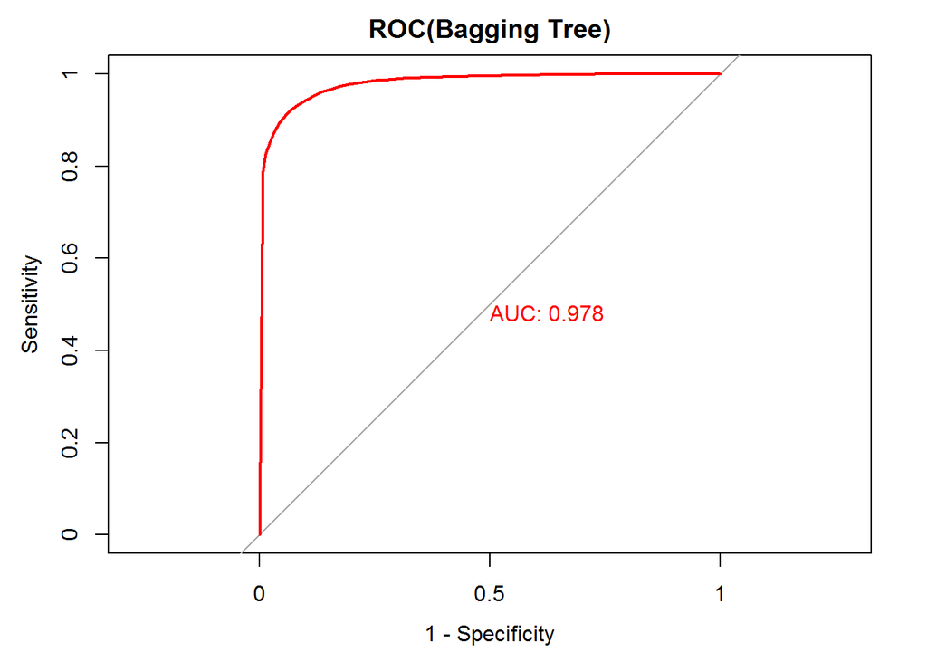

```r
predict_loan_status_bag = predict(bag.model, test, 'prob')
predict_loan_status_bag = as.data.frame(predict_loan_status_bag)$Fully.Paid

rocCurve_bag = roc(response = test$loan_status, predictor = predict_loan_status_bag)
auc_curve = auc(rocCurve_bag)

plot(rocCurve_bag,legacy.axes = TRUE,print.auc = TRUE,col="red",main="ROC(Bagging Tree)")
```

Combine Metrics

```r
predict_loan_status_label = ifelse(predict_loan_status_bag <0.3,"Default","Fully.Paid")
c = confusionMatrix(predict_loan_status_label,test$loan_status, positive="Fully.Paid")

table_perf[3,] = c("Bagging Tree",
  round(auc_curve,3),
  as.numeric(round(c$overall["Accuracy"],3)),
  as.numeric(round(c$byClass["Sensitivity"],3)),
  as.numeric(round(c$byClass["Specificity"],3)),
  as.numeric(round(c$overall["Kappa"],3))
  )

tail(table_perf,1)
```

```
##          model   auc accuracy sensitivity specificity kappa
## 3 Bagging Tree 0.978    0.939       0.988        0.72 0.777
```

```r
factorize <- function (data)
{
  data$state_default_level <- as.factor(data$state_default_level)
  data$emp_length_sim <- as.factor(data$emp_length_sim)
  data$home_ownership1 <- as.factor(data$home_ownership1)
  data$verification_status <- as.factor(data$verification_status)
  data$inq_last_6mths_level <- as.factor(data$inq_last_6mths_level)
  data$delinq_2yrs_level <- as.factor(data$delinq_2yrs_level)
  data$collections_12_mths_ex_med_level <- as.factor(data$collections_12_mths_ex_med_level)
  data$term <- as.factor(data$term)
  data$initial_list_status <- as.factor(data$initial_list_status)
 return (data)
}
```

### Random Forest

```r
library(randomForest)
train$state_default_level <- as.factor(train$state_default_level)
train$emp_length_sim <- as.factor(train$emp_length_sim)
train$home_ownership1 <- as.factor(train$home_ownership1)
train$verification_status <- as.factor(train$verification_status)
train$inq_last_6mths_level <- as.factor(train$inq_last_6mths_level)
train$delinq_2yrs_level <- as.factor(train$delinq_2yrs_level)
train$collections_12_mths_ex_med <- as.factor(train$collections_12_mths_ex_med)
train$purpose <- as.factor(train$purpose)
train$term <- as.factor(train$term)
train$initial_list_status <- as.factor(train$initial_list_status)
train$pub_rec <- as.factor(train$pub_rec)
```

```r
train.char <- sapply(train, is.character)
names(train.char)[which(train.char == T)]
```

```
## character(0)
```

```r
set.seed(2)
rf <- randomForest(loan_status ~., data = train, importance = TRUE, do.trace = TRUE, nodesize = 500, ntree = 30)
```

```
## ntree      OOB      1      2
##     1:   8.95% 25.29%  5.24%
##     2:  10.61% 33.92%  5.32%
##     3:   9.97% 30.27%  5.38%
##     4:   9.61% 28.99%  5.23%
##     5:   9.74% 29.10%  5.36%
##     6:  10.23% 33.32%  5.02%
##     7:   9.77% 31.31%  4.91%
##     8:   9.81% 31.61%  4.89%
##     9:   9.83% 31.26%  4.99%
##    10:   9.72% 30.60%  5.00%
##    11:   9.64% 30.39%  4.96%
##    12:   9.55% 29.98%  4.94%
##    13:   9.55% 30.11%  4.91%
##    14:   9.57% 30.66%  4.81%
```

[output cut: 16 more lines]

#### Plot Importance

[figure not shown]

```r
varImpPlot(rf)
```

#### Predict and Plot

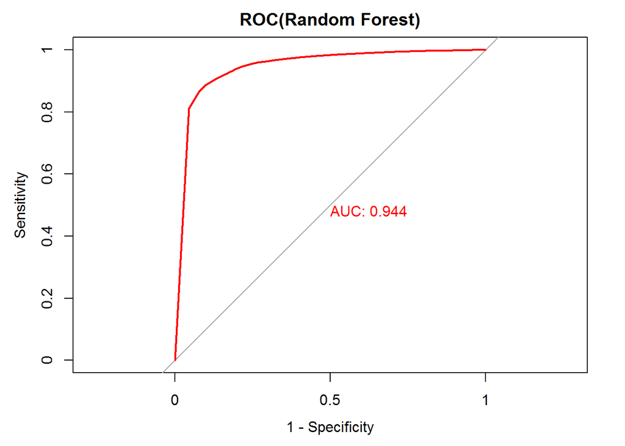

```r
# test
test$state_default_level <- as.factor(test$state_default_level)
test$emp_length_sim <- as.factor(test$emp_length_sim)
test$home_ownership1 <- as.factor(test$home_ownership1)
test$verification_status <- as.factor(test$verification_status)
test$inq_last_6mths_level <- as.factor(test$inq_last_6mths_level)
test$delinq_2yrs_level <- as.factor(test$delinq_2yrs_level)
test$collections_12_mths_ex_med <- as.factor(test$collections_12_mths_ex_med)
test$purpose <- as.factor(test$purpose)
test$term <- as.factor(test$term)
test$initial_list_status <- as.factor(test$initial_list_status)
test$pub_rec <- as.factor(test$pub_rec)

predict_loan_status_rf = predict(rf, test, 'prob')
predict_loan_status_rf = as.data.frame(predict_loan_status_rf)$Fully.Paid

rocCurve_rf = roc(response = test$loan_status, predictor = predict_loan_status_rf)
auc_curve = auc(rocCurve_rf)

plot(rocCurve_rf,legacy.axes = TRUE,print.auc = TRUE,col="red",main="ROC(Random Forest)")
```

Combine Metrics

```r
predict_loan_status_label = ifelse(predict_loan_status_rf <0.3,"Default","Fully.Paid")
c = confusionMatrix(predict_loan_status_label,test$loan_status, positive="Fully.Paid")

table_perf[4,] = c("Random Forest",
  round(auc_curve,3),
  as.numeric(round(c$overall["Accuracy"],3)),
  as.numeric(round(c$byClass["Sensitivity"],3)),
  as.numeric(round(c$byClass["Specificity"],3)),
  as.numeric(round(c$overall["Kappa"],3))
  )

tail(table_perf,1)
```

```
##           model   auc accuracy sensitivity specificity kappa
## 4 Random Forest 0.944    0.901        0.98       0.545 0.612
```

### Boosting

```r
library(xgboost)

feature.matrix  <- model.matrix( ~., train[, -1])
train.label <- as.numeric(train$loan_status) - 1
gbt <- xgboost(data =  feature.matrix,
               label = train.label,
               max_depth = 8, # for each tree, how deep it goes
               nround = 100, # number of trees
               objective = "binary:logistic",
               eval_metric = "auc",
               nthread = -1,
               verbose = 1)
```

#### Predict and Plot

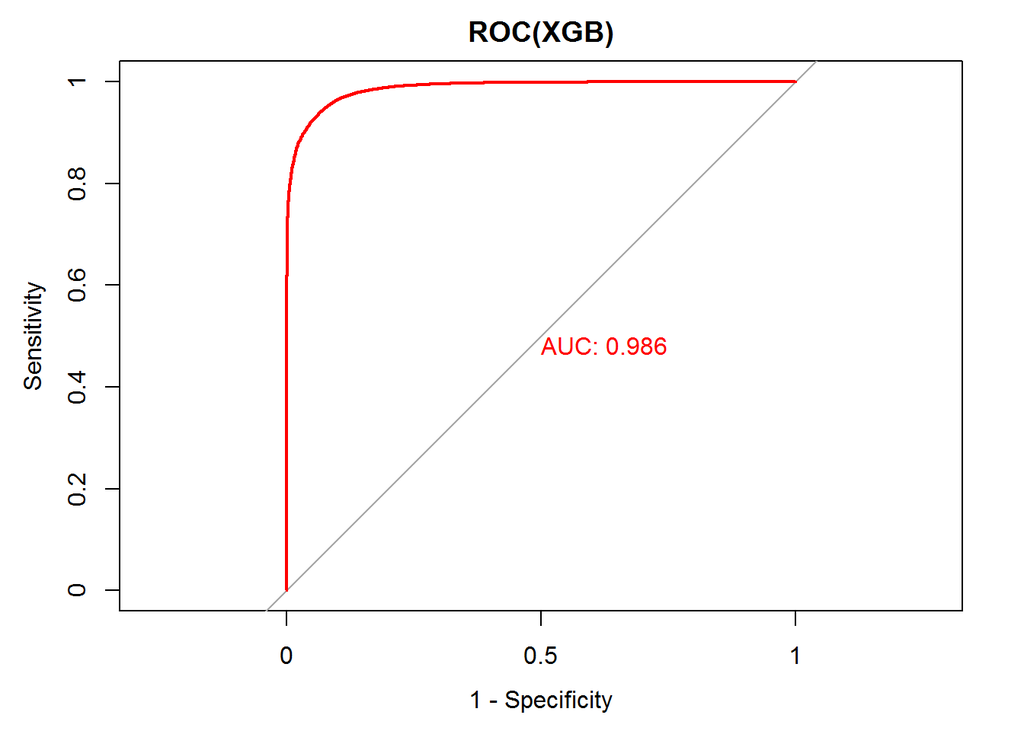

```r
test.feature.matrix  <- model.matrix( ~., test[, -1])
predict_loan_status_xgb = predict(gbt, test.feature.matrix)

rocCurve_xgb = roc(response = test$loan_status,predictor = predict_loan_status_xgb)
auc_curve = auc(rocCurve_xgb)

plot(rocCurve_xgb,legacy.axes = TRUE,print.auc = TRUE,col="red",main="ROC(XGB)")
```

Combine Metrics

```r
predict_loan_status_label = ifelse(predict_loan_status_xgb <0.3,"Default","Fully.Paid")
c = confusionMatrix(predict_loan_status_label,test$loan_status, positive="Fully.Paid")

table_perf[5,] = c("XGB",
  round(auc_curve,3),
  as.numeric(round(c$overall["Accuracy"],3)),
  as.numeric(round(c$byClass["Sensitivity"],3)),
  as.numeric(round(c$byClass["Specificity"],3)),
  as.numeric(round(c$overall["Kappa"],3))
  )

tail(table_perf,1)
```

```
##   model   auc accuracy sensitivity specificity kappa
## 5   XGB 0.986    0.952       0.991       0.777 0.826
```

### Averaging Ensemble

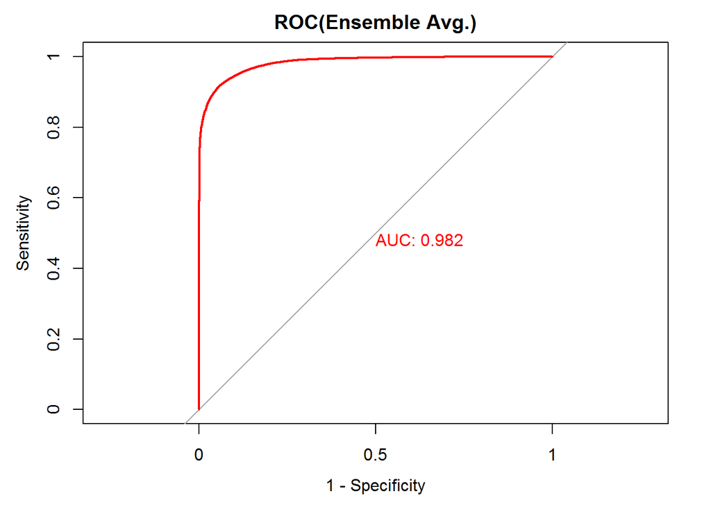

```r
predict_loan_status_ensemble = predict_loan_status_lr +
                               predict_loan_status_tree +
                               predict_loan_status_bag +
                               predict_loan_status_rf +
                               predict_loan_status_xgb

predict_loan_status_ensemble = predict_loan_status_ensemble / 5
rocCurve_ensemble = roc(response = test$loan_status, predictor = predict_loan_status_ensemble)

auc_curve = auc(rocCurve_ensemble)
plot(rocCurve_ensemble,legacy.axes = TRUE,print.auc = TRUE,col="red",main="ROC(Ensemble Avg.)")
```

Combine Metrics

```r
predict_loan_status_label = ifelse(predict_loan_status_ensemble < 0.3,"Default","Fully.Paid")
c = confusionMatrix(predict_loan_status_label,test$loan_status, positive="Fully.Paid")

table_perf[6,] = c("Ensemble",
  round(auc_curve,3),
  as.numeric(round(c$overall["Accuracy"],3)),
  as.numeric(round(c$byClass["Sensitivity"],3)),
  as.numeric(round(c$byClass["Specificity"],3)),
  as.numeric(round(c$overall["Kappa"],3))
  )

tail(table_perf,1)
```

```
##      model   auc accuracy sensitivity specificity kappa
## 6 Ensemble 0.982    0.936       0.992       0.689 0.762
```

## Compare Model

```r
table_perf
```

```
##                 model   auc accuracy sensitivity specificity kappa
## 1 logistic regression 0.949    0.876       0.981       0.409 0.485
## 2         Single Tree 0.973    0.942        0.98       0.773 0.796
## 3        Bagging Tree 0.978    0.939       0.988        0.72 0.777
## 4       Random Forest 0.944    0.901        0.98       0.545 0.612
## 5                 XGB 0.986    0.952       0.991       0.777 0.826
## 6            Ensemble 0.982    0.936       0.992       0.689 0.762
```

Create a figure to combine the ROC curves for all models

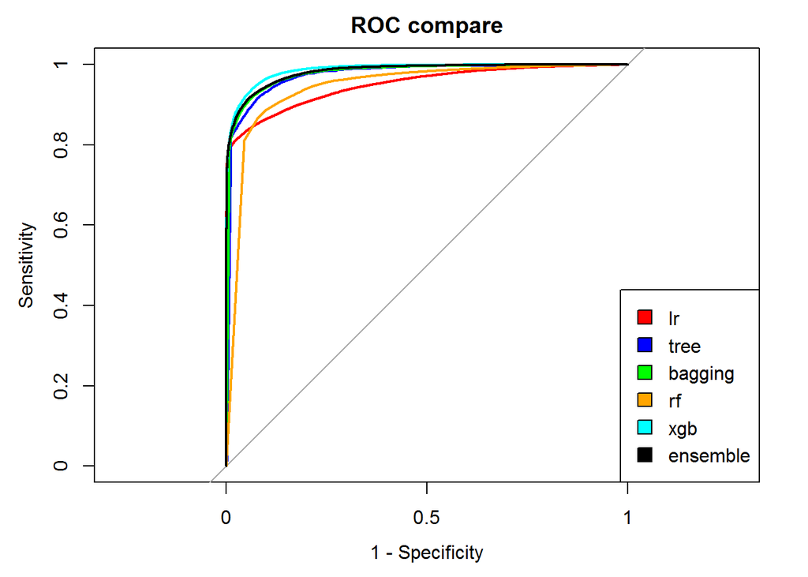

```r
plot(rocCurve_lr,legacy.axes = TRUE,col="red",main="ROC compare")
plot(rocCurve_tree,legacy.axes = TRUE,col="blue",add=TRUE)
plot(rocCurve_bag,legacy.axes = TRUE,col="green",add=TRUE)
plot(rocCurve_rf,legacy.axes = TRUE,col="orange",add=TRUE)
plot(rocCurve_xgb,legacy.axes = TRUE,col="cyan",add=TRUE)
plot(rocCurve_ensemble,legacy.axes = TRUE,col="black",add=TRUE)

legend("bottomright",legend=c("lr","tree","bagging","rf","xgb", "ensemble"),fill=c("red","blue","green","orange","cyan", "black"))
```